# TRABAJO INDIVIDUAL FEADE-AEDM

**B. Estudia la normalidad de los valores de expresión de cada gen a través de los gráficos cuantil-cuantil y de los contrastes de normalidad adecuados.**

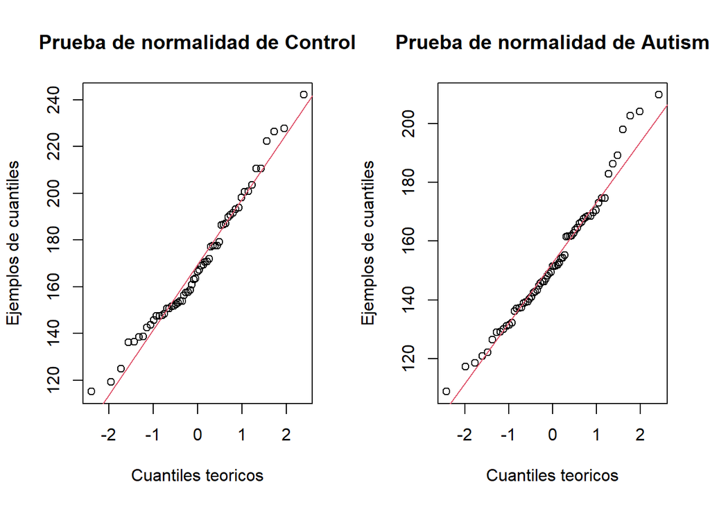

```r
#ESTUDIO DE NORMALIDAD MEDIANTE REPRESENTACIÓN CAUNTIL-CUANTIL (QQ-PLOT)

o=par(mfrow=c(1,2))

#gen x.205486_at
qqnorm(datos.autismo$x.205486_at[datos.autismo$factor=="Control"], xlab = "Cuantiles teoricos", ylab = "Ejemplos de cuantiles",main = "Prueba de normalidad de Control");qqline(datos.autismo$x.205486_at[datos.autismo$factor=="Control"],col=2)
qqnorm(datos.autismo$x.205486_at[datos.autismo$factor=="Autism"], xlab = "Cuantiles teoricos", ylab = "Ejemplos de cuantiles",main = "Prueba de normalidad de Autism");qqline(datos.autismo$x.205486_at[datos.autismo$factor=="Autism"],col=2)
```

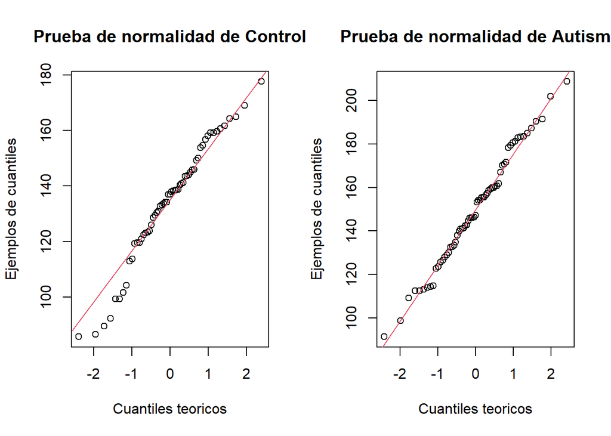

```r
o=par(mfrow=c(1,2))
#gen x.234972_at
qqnorm(datos.autismo$x.234972_at[datos.autismo$factor=="Control"], xlab = "Cuantiles teoricos", ylab = "Ejemplos de cuantiles",main = "Prueba de normalidad de Control");qqline(datos.autismo$x.234972_at[datos.autismo$factor=="Control"],col=2)
qqnorm(datos.autismo$x.234972_at[datos.autismo$factor=="Autism"], xlab = "Cuantiles teoricos", ylab = "Ejemplos de cuantiles",main = "Prueba de normalidad de Autism");qqline(datos.autismo$x.234972_at[datos.autismo$factor=="Autism"],col=2)
```

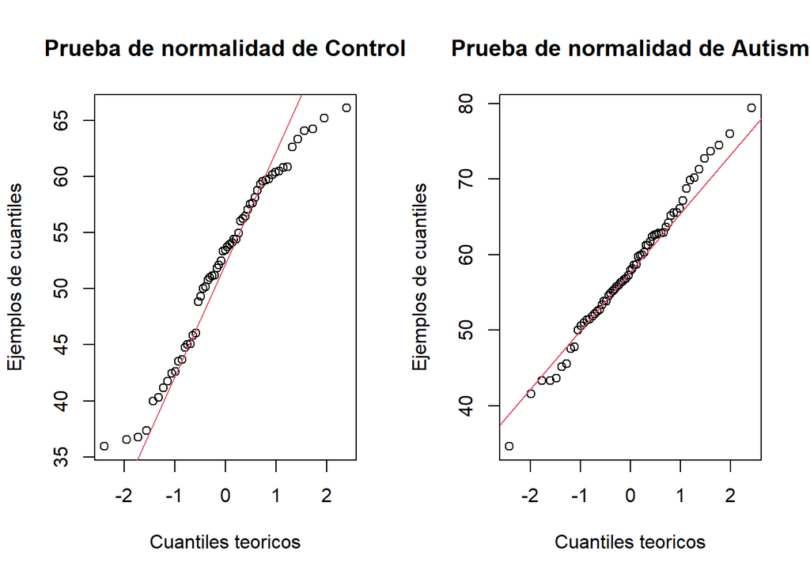

```r
o=par(mfrow=c(1,2))
#gen x.212848_s_at
qqnorm(datos.autismo$x.212848_s_at[datos.autismo$factor=="Control"], xlab = "Cuantiles teoricos", ylab = "Ejemplos de cuantiles",main = "Prueba de normalidad de Control");qqline(datos.autismo$x.212848_s_at[datos.autismo$factor=="Control"],col=2)
qqnorm(datos.autismo$x.212848_s_at[datos.autismo$factor=="Autism"], xlab = "Cuantiles teoricos", ylab = "Ejemplos de cuantiles",main = "Prueba de normalidad de Autism");qqline(datos.autismo$x.212848_s_at[datos.autismo$factor=="Autism"],col=2)
```

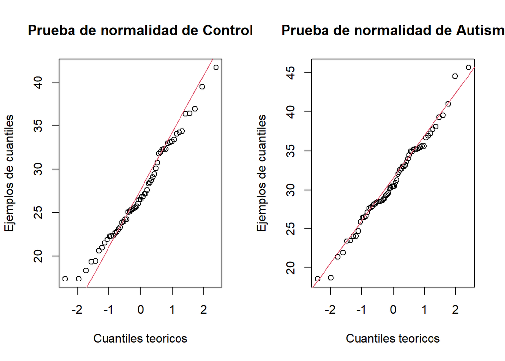

```r
o=par(mfrow=c(1,2))
#gen x.232674_at
qqnorm(datos.autismo$x.232674_at[datos.autismo$factor=="Control"], xlab = "Cuantiles teoricos", ylab = "Ejemplos de cuantiles",main = "Prueba de normalidad de Control");qqline(datos.autismo$x.232674_at[datos.autismo$factor=="Control"],col=2)
qqnorm(datos.autismo$x.232674_at[datos.autismo$factor=="Autism"], xlab = "Cuantiles teoricos", ylab = "Ejemplos de cuantiles",main = "Prueba de normalidad de Autism");qqline(datos.autismo$x.232674_at[datos.autismo$factor=="Autism"],col=2)
```

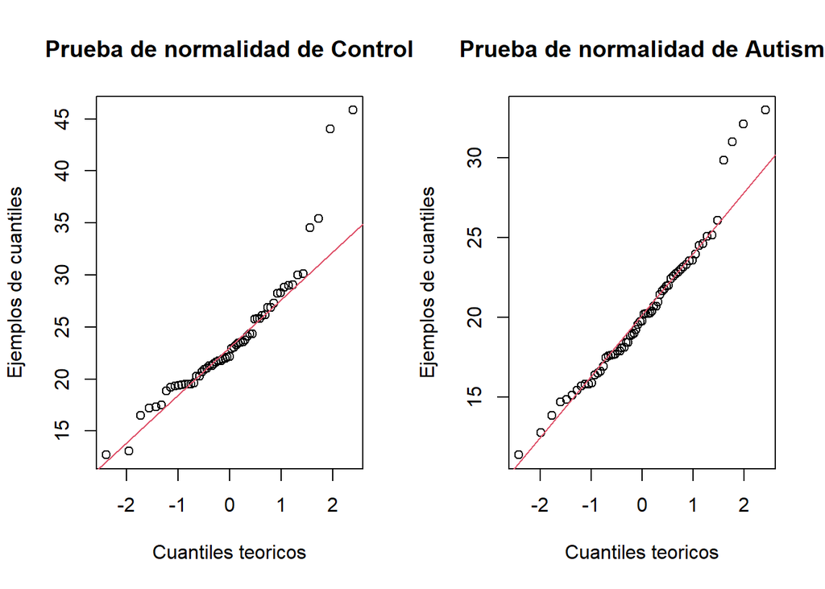

```r
o=par(mfrow=c(1,2))
#gen x.235889_at
qqnorm(datos.autismo$x.235889_at[datos.autismo$factor=="Control"], xlab = "Cuantiles teoricos", ylab = "Ejemplos de cuantiles",main = "Prueba de normalidad de Control");qqline(datos.autismo$x.235889_at[datos.autismo$factor=="Control"],col=2)
qqnorm(datos.autismo$x.235889_at[datos.autismo$factor=="Autism"], xlab = "Cuantiles teoricos", ylab = "Ejemplos de cuantiles",main = "Prueba de normalidad de Autism");qqline(datos.autismo$x.235889_at[datos.autismo$factor=="Autism"],col=2)
```

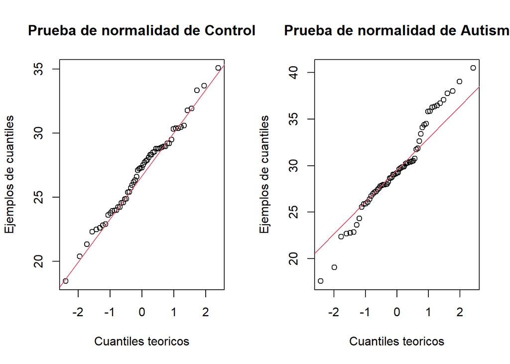

```r
o=par(mfrow=c(1,2))
#gen x.1553235_at
qqnorm(datos.autismo$x.1553235_at[datos.autismo$factor=="Control"], xlab = "Cuantiles teoricos", ylab = "Ejemplos de cuantiles",main = "Prueba de normalidad de Control");qqline(datos.autismo$x.1553235_at[datos.autismo$factor=="Control"],col=2)
qqnorm(datos.autismo$x.1553235_at[datos.autismo$factor=="Autism"], xlab = "Cuantiles teoricos", ylab = "Ejemplos de cuantiles",main = "Prueba de normalidad de Autism");qqline(datos.autismo$x.1553235_at[datos.autismo$factor=="Autism"],col=2)
```

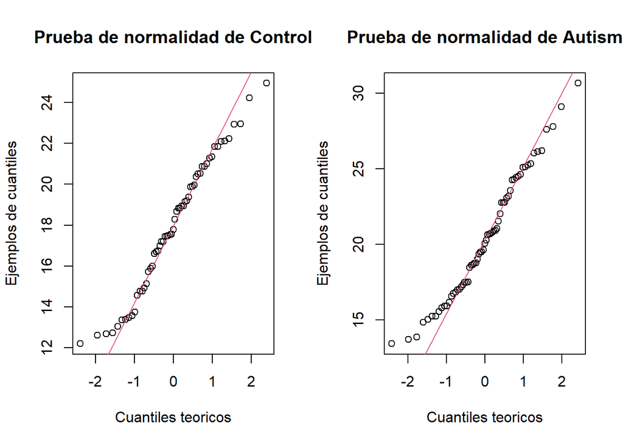

```r
o=par(mfrow=c(1,2))
#gen x.244494_at
qqnorm(datos.autismo$x.244494_at[datos.autismo$factor=="Control"], xlab = "Cuantiles teoricos", ylab = "Ejemplos de cuantiles",main = "Prueba de normalidad de Control");qqline(datos.autismo$x.244494_at[datos.autismo$factor=="Control"],col=2)
qqnorm(datos.autismo$x.244494_at[datos.autismo$factor=="Autism"], xlab = "Cuantiles teoricos", ylab = "Ejemplos de cuantiles",main = "Prueba de normalidad de Autism");qqline(datos.autismo$x.244494_at[datos.autismo$factor=="Autism"],col=2)
```

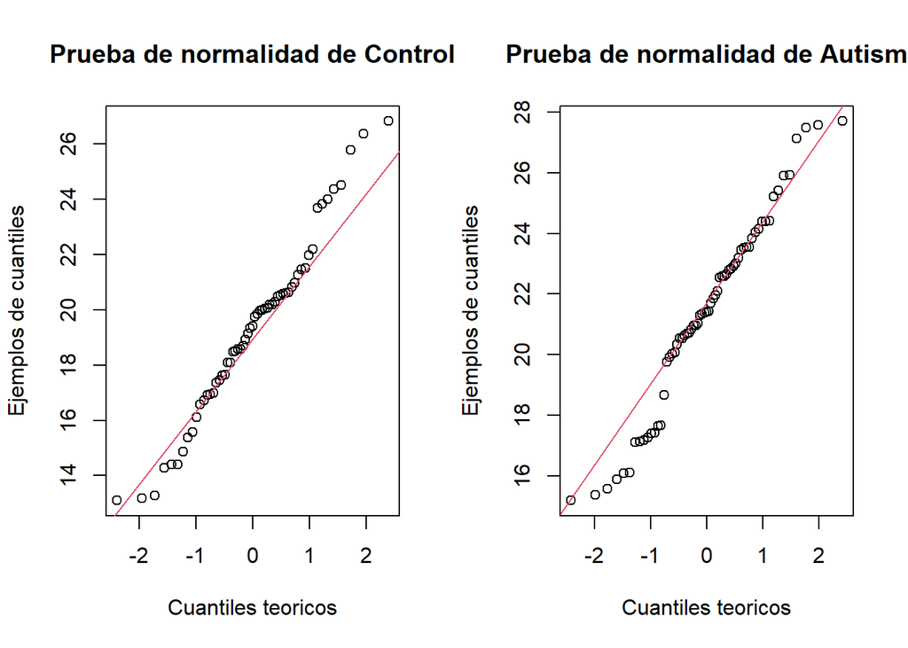

```r
o=par(mfrow=c(1,2))
#gen x.233835_at
qqnorm(datos.autismo$x.233835_at[datos.autismo$factor=="Control"], xlab = "Cuantiles teoricos", ylab = "Ejemplos de cuantiles",main = "Prueba de normalidad de Control");qqline(datos.autismo$x.233835_at[datos.autismo$factor=="Control"],col=2)
qqnorm(datos.autismo$x.233835_at[datos.autismo$factor=="Autism"], xlab = "Cuantiles teoricos", ylab = "Ejemplos de cuantiles",main = "Prueba de normalidad de Autism");qqline(datos.autismo$x.233835_at[datos.autismo$factor=="Autism"],col=2)
```

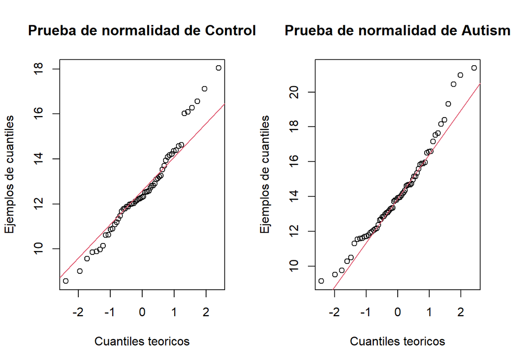

```r
o=par(mfrow=c(1,2))
#gen x.242767_at
qqnorm(datos.autismo$x.242767_at[datos.autismo$factor=="Control"], xlab = "Cuantiles teoricos", ylab = "Ejemplos de cuantiles",main = "Prueba de normalidad de Control");qqline(datos.autismo$x.242767_at[datos.autismo$factor=="Control"],col=2)
qqnorm(datos.autismo$x.242767_at[datos.autismo$factor=="Autism"], xlab = "Cuantiles teoricos", ylab = "Ejemplos de cuantiles",main = "Prueba de normalidad de Autism");qqline(datos.autismo$x.242767_at[datos.autismo$factor=="Autism"],col=2)
```

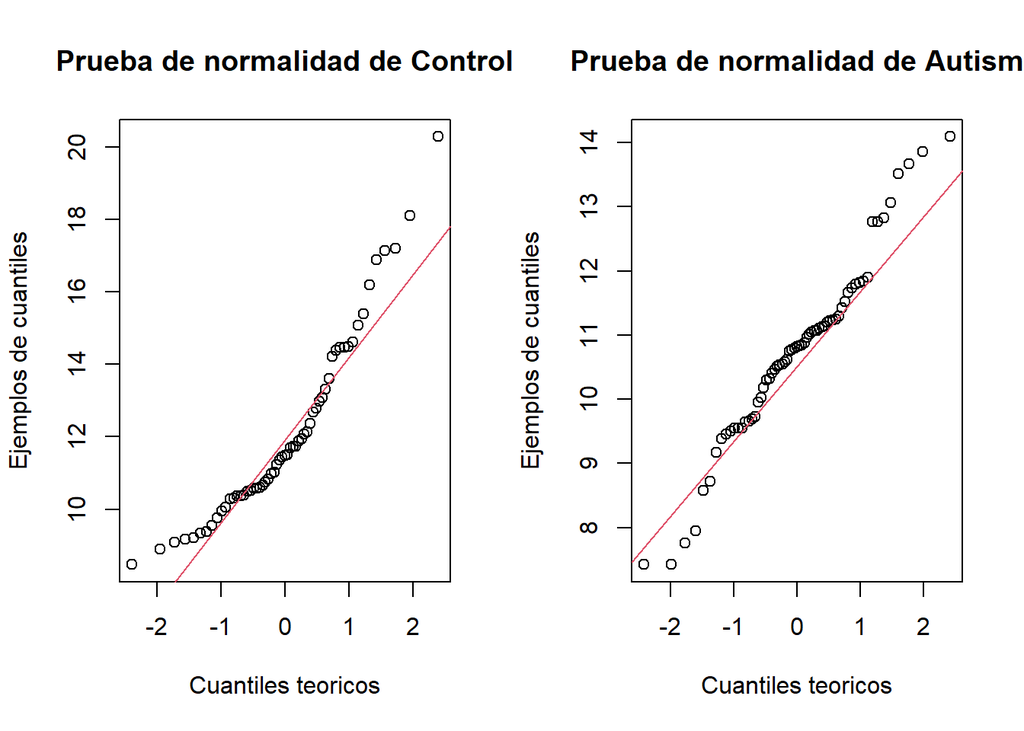

```r
o=par(mfrow=c(1,2))
#gen x.1552734_at
qqnorm(datos.autismo$x.1552734_at[datos.autismo$factor=="Control"], xlab = "Cuantiles teoricos", ylab = "Ejemplos de cuantiles",main = "Prueba de normalidad de Control");qqline(datos.autismo$x.1552734_at[datos.autismo$factor=="Control"],col=2)
qqnorm(datos.autismo$x.1552734_at[datos.autismo$factor=="Autism"], xlab = "Cuantiles teoricos", ylab = "Ejemplos de cuantiles",main = "Prueba de normalidad de Autism");qqline(datos.autismo$x.1552734_at[datos.autismo$factor=="Autism"],col=2)
```

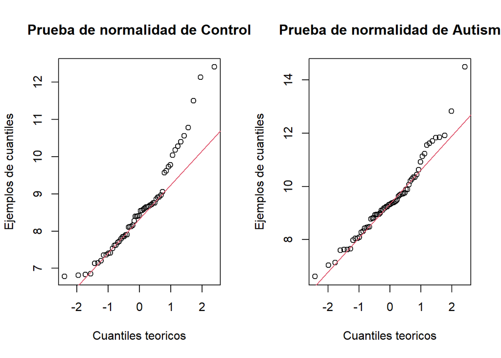

```r
o=par(mfrow=c(1,2))
#gen x.242980_at
qqnorm(datos.autismo$x.242980_at[datos.autismo$factor=="Control"], xlab = "Cuantiles teoricos", ylab = "Ejemplos de cuantiles",main = "Prueba de normalidad de Control");qqline(datos.autismo$x.242980_at[datos.autismo$factor=="Control"],col=2)
qqnorm(datos.autismo$x.242980_at[datos.autismo$factor=="Autism"], xlab = "Cuantiles teoricos", ylab = "Ejemplos de cuantiles",main = "Prueba de normalidad de Autism");qqline(datos.autismo$x.242980_at[datos.autismo$factor=="Autism"],col=2)
```

*Interpretación*

Podemos apreciar en la gran mayoría de las gráficas que los datos parecen ajustarse a una distribución normal en mayor o menor medida. Para contrastar esto debemos acudir a los test correspondientes que midan esta tendencia para asumir dicha distribución.

**C. Contrasta la igualdad de medias de los valores de expresión para cada gen entre individuos autistas y de control. Interpreta los resultados. Explica tu consideración sobre la adecuación de la prueba paramétrica aplicada. Indica justificadamente qué genes se expresan diferencialmente**

```r
summary(datos.autismo$factor)
```

```
##  Autism Control
##      65      59
```

En nuestro caso, tenemos un tamaño de muestra ligeramente superior a 50. No usaremos test de Shapiro-Wilks (adecuado para n<50) y usaremos Kolmogorov-Smirnov. Este test, contrasta la hipotesis nula de que el conjunto se ajusta a una normal, si la rechazamos asuminos que el conjunto de datos no se ajusta a una distribución normal.

```r
library(nortest)
#gen x.205486_at
ks.test(datos.autismo$x.205486_at,pnorm,mean(datos.autismo$x.205486_at),sd(datos.autismo$x.205486_at))
```

```
##
##  Asymptotic one-sample Kolmogorov-Smirnov test
##
## data:  datos.autismo$x.205486_at
## D = 0.09221, p-value = 0.2424
## alternative hypothesis: two-sided
```

El conjunto de datos de la variable se ajusta a una D.normal (p>0.05)

```r
#gen x.234972_at
ks.test(datos.autismo$x.234972_at,pnorm,mean(datos.autismo$x.234972_at),sd(datos.autismo$x.234972_at))
```

```
##
##  Asymptotic one-sample Kolmogorov-Smirnov test
##
## data:  datos.autismo$x.234972_at
## D = 0.051176, p-value = 0.9015
## alternative hypothesis: two-sided
```

El conjunto de datos de la variable se ajusta a una D.normal (p>0.05)

```r
#gen x.212848_s_at
ks.test(datos.autismo$x.212848_s_at,pnorm,mean(datos.autismo$x.212848_s_at),sd(datos.autismo$x.212848_s_at))
```

```
##
##  Asymptotic one-sample Kolmogorov-Smirnov test
##
## data:  datos.autismo$x.212848_s_at
## D = 0.051388, p-value = 0.8988
## alternative hypothesis: two-sided
```

El conjunto de datos de la variable se ajusta a una D.normal (p>0.05)

```r
#gen x.232674_at
ks.test(datos.autismo$x.232674_at,pnorm,mean(datos.autismo$x.232674_at),sd(datos.autismo$x.232674_at))
```

```
##
##  Asymptotic one-sample Kolmogorov-Smirnov test
##
## data:  datos.autismo$x.232674_at
## D = 0.044663, p-value = 0.9656
## alternative hypothesis: two-sided
```

El conjunto de datos de la variable se ajusta a una D.normal (p>0.05)

```r
#gen x.235889_at
ks.test(datos.autismo$x.235889_at,pnorm,mean(datos.autismo$x.235889_at),sd(datos.autismo$x.235889_at))
```

```
##
##  Asymptotic one-sample Kolmogorov-Smirnov test
##
## data:  datos.autismo$x.235889_at
## D = 0.11163, p-value = 0.09096
## alternative hypothesis: two-sided
```

El conjunto de datos de la variable se ajusta a una D.normal (p>0.05)

```r
#gen x.1553235_at
ks.test(datos.autismo$x.1553235_at,pnorm,mean(datos.autismo$x.1553235_at),sd(datos.autismo$x.1553235_at))
```

```
##
##  Asymptotic one-sample Kolmogorov-Smirnov test
##
## data:  datos.autismo$x.1553235_at
## D = 0.11153, p-value = 0.09146
## alternative hypothesis: two-sided
```

El conjunto de datos de la variable se ajusta a una D.normal (p>0.05)

```r
#gen x.244494_at
ks.test(datos.autismo$x.244494_at,pnorm,mean(datos.autismo$x.244494_at),sd(datos.autismo$x.244494_at))
```

```
##
##  Asymptotic one-sample Kolmogorov-Smirnov test
##
## data:  datos.autismo$x.244494_at
## D = 0.078359, p-value = 0.4317
## alternative hypothesis: two-sided
```

El conjunto de datos de la variable se ajusta a una D.normal (p>0.05)

```r
#gen x.233835_at
ks.test(datos.autismo$x.233835_at,pnorm,mean(datos.autismo$x.233835_at),sd(datos.autismo$x.233835_at))
```

```
##
##  Asymptotic one-sample Kolmogorov-Smirnov test
##
## data:  datos.autismo$x.233835_at
## D = 0.062066, p-value = 0.7259
## alternative hypothesis: two-sided
```

El conjunto de datos de la variable se ajusta a una D.normal (p>0.05)

```r
#gen x.242767_at
ks.test(datos.autismo$x.242767_at,pnorm,mean(datos.autismo$x.242767_at),sd(datos.autismo$x.242767_at))
```

```
##
##  Asymptotic one-sample Kolmogorov-Smirnov test
##
## data:  datos.autismo$x.242767_at
## D = 0.091829, p-value = 0.2466
## alternative hypothesis: two-sided
```

El conjunto de datos de la variable se ajusta a una D.normal (p>0.05)

```r
#gen x.1552734_at
ks.test(datos.autismo$x.1552734_at,pnorm,mean(datos.autismo$x.1552734_at),sd(datos.autismo$x.1552734_at))
```

```
##
##  Asymptotic one-sample Kolmogorov-Smirnov test
##
## data:  datos.autismo$x.1552734_at
## D = 0.15013, p-value = 0.007475
## alternative hypothesis: two-sided
```

El conjunto de datos de la variable **NO** se ajusta a una D.normal (p<0.05)

```r
#gen x.242980_at
ks.test(datos.autismo$x.242980_at,pnorm,mean(datos.autismo$x.242980_at),sd(datos.autismo$x.242980_at))
```

```
##
##  Asymptotic one-sample Kolmogorov-Smirnov test
##
## data:  datos.autismo$x.242980_at
## D = 0.082714, p-value = 0.3643
## alternative hypothesis: two-sided
```

El conjunto de datos de la variable se ajusta a una D.normal (p>0.05)

CONTRASTE DE IGUALDAD DE MEDIAS(D.NORMAL) O DE MEDIANAS(D. NO NORMAL).

En este caso, el test elegido para contrastar las medias será Prueba de Student (t.test).

Adecuada, ya que quiero comparar la igualdad entre dos medias de muestras independientes (control y Autism). Para ello, primero realizo test de varianzas ya que tengo que declarar en t.test como son (significativamente similares o distintas).

```r
#gen x.205486_at -> D.normal (Contraste de medias)
var.test(datos.autismo$x.205486_at~datos.autismo$factor)
```

```
##
##  F test to compare two variances
##
## data:  datos.autismo$x.205486_at by datos.autismo$factor
## F = 0.61782, num df = 64, denom df = 58, p-value = 0.06104
## alternative hypothesis: true ratio of variances is not equal to 1
## 95 percent confidence interval:
##  0.3708311 1.0227455
## sample estimates:
## ratio of variances
##          0.6178184
```

p.value>0.05 -> no rechazo H0 -> no hay evidencia de diferencias significativas -> varianzas similares.

```r
t.test(datos.autismo$x.205486_at~ datos.autismo$factor,var.equal=T)
```

```
##
##  Two Sample t-test
##
## data:  datos.autismo$x.205486_at by datos.autismo$factor
## t = -3.7041, df = 122, p-value = 0.00032
## alternative hypothesis: true difference in means between group Autism and group Control is not equal to 0
## 95 percent confidence interval:
##  -25.244947  -7.659737
## sample estimates:
##  mean in group Autism mean in group Control
##              153.1099              169.5622
```

p.value<0.05 -> rechazamos hipotesis nula de que las medias son iguales -> gen se expresa diferencialmente entre clases (medias distintas).

```r
#gen x.234972_at -> D.normal (Contraste de medias)
var.test(datos.autismo$x.234972_at~datos.autismo$factor)
```

```
##
##  F test to compare two variances
##
## data:  datos.autismo$x.234972_at by datos.autismo$factor
## F = 1.4614, num df = 64, denom df = 58, p-value = 0.1441
## alternative hypothesis: true ratio of variances is not equal to 1
## 95 percent confidence interval:
##  0.8771728 2.4192269
## sample estimates:
## ratio of variances
##           1.461402
```

p.value>0.05 -> no rechazo H0 -> no hay evidencia de diferencias significativas -> varianzas similares

```r
t.test(datos.autismo$x.234972_at~ datos.autismo$factor,var.equal=T)
```

```
##
##  Two Sample t-test
##
## data:  datos.autismo$x.234972_at by datos.autismo$factor
## t = 3.5958, df = 122, p-value = 0.0004678
## alternative hypothesis: true difference in means between group Autism and group Control is not equal to 0
## 95 percent confidence interval:
##   6.948588 23.970126
## sample estimates:
##  mean in group Autism mean in group Control
##              149.7894              134.3301
```

p.value<0.05 -> rechazamos hipotesis nula de que las medias son iguales -> gen se expresa diferencialmente entre clases (medias distintas).

```r
#gen x.212848_s_at -> D.normal (Contraste de medias)
var.test(datos.autismo$x.212848_s_at~datos.autismo$factor)
```

```
##
##  F test to compare two variances
##
## data:  datos.autismo$x.212848_s_at by datos.autismo$factor
## F = 1.2306, num df = 64, denom df = 58, p-value = 0.4239
## alternative hypothesis: true ratio of variances is not equal to 1
## 95 percent confidence interval:
##  0.738639 2.037153
## sample estimates:
## ratio of variances
##             1.2306
```

p.value>0.05 -> no rechazo H0 -> no hay evidencia de diferencias significativas -> varianzas similares.

```r
t.test(datos.autismo$x.212848_s_at~ datos.autismo$factor,var.equal=T)
```

```
##
##  Two Sample t-test
##
## data:  datos.autismo$x.212848_s_at by datos.autismo$factor
## t = 3.83, df = 122, p-value = 0.0002038
## alternative hypothesis: true difference in means between group Autism and group Control is not equal to 0
## 95 percent confidence interval:
##  2.845664 8.934427
## sample estimates:
##  mean in group Autism mean in group Control
##              58.17349              52.28344
```

p.value<0.05 -> rechazamos hipotesis nula de que las medias son iguales -> gen se expresa diferencialmente entre clases (medias distintas).

```r
#gen x.232674_at -> D.normal (Contraste de medias)
var.test(datos.autismo$x.232674_at~datos.autismo$factor)
```

```
##
##  F test to compare two variances
##
## data:  datos.autismo$x.232674_at by datos.autismo$factor
## F = 0.98766, num df = 64, denom df = 58, p-value = 0.9582
## alternative hypothesis: true ratio of variances is not equal to 1
## 95 percent confidence interval:
##  0.5928192 1.6349846
## sample estimates:
## ratio of variances
##          0.9876588
```

p.value>0.05 -> no rechazo H0 -> no hay evidencia de diferencias significativas -> varianzas similares.

```r
t.test(datos.autismo$x.232674_at~ datos.autismo$factor,var.equal=T)
```

```
##
##  Two Sample t-test
##
## data:  datos.autismo$x.232674_at by datos.autismo$factor
## t = 3.6568, df = 122, p-value = 0.0003781
## alternative hypothesis: true difference in means between group Autism and group Control is not equal to 0
## 95 percent confidence interval:
##  1.683642 5.658103
## sample estimates:
##  mean in group Autism mean in group Control
##              31.07247              27.40159
```

p.value<0.05 -> rechazamos hipotesis nula de que las medias son iguales -> gen se expresa diferencialmente entre clases (medias distintas).

```r
#gen x.235889_at -> D.normal (Contraste de medias)
var.test(datos.autismo$x.235889_at~datos.autismo$factor)
```

```
##
##  F test to compare two variances
##
## data:  datos.autismo$x.235889_at by datos.autismo$factor
## F = 0.52562, num df = 64, denom df = 58, p-value = 0.01261
## alternative hypothesis: true ratio of variances is not equal to 1
## 95 percent confidence interval:
##  0.3154887 0.8701123
## sample estimates:
## ratio of variances
##           0.525616
```

p.value<0.05 -> rechazo H0 , hay diferencias significativas entre varianzas. En este caso hacemos test de Welch al declarar varianzas distintas -> p<0.05 -> rechazo H0

```r
t.test(datos.autismo$x.235889_at~ datos.autismo$factor,var.equal=F)
```

```
##
##  Welch Two Sample t-test
##
## data:  datos.autismo$x.235889_at by datos.autismo$factor
## t = -3.6698, df = 104.91, p-value = 0.0003836
## alternative hypothesis: true difference in means between group Autism and group Control is not equal to 0
## 95 percent confidence interval:
##  -5.366937 -1.601680
## sample estimates:
##  mean in group Autism mean in group Control
##              20.23372              23.71802
```

Gen se expresa diferencialmente entre clases (medias distintas).

```r
#gen x.1553235_at -> D.normal (Contraste de medias)
var.test(datos.autismo$x.1553235_at~datos.autismo$factor)
```

```
##
##  F test to compare two variances
##
## data:  datos.autismo$x.1553235_at by datos.autismo$factor
## F = 1.9562, num df = 64, denom df = 58, p-value = 0.01032
## alternative hypothesis: true ratio of variances is not equal to 1
## 95 percent confidence interval:
##  1.174190 3.238394
## sample estimates:
## ratio of variances
##           1.956243
```

p.value<0.05 -> rechazo H0 , hay diferencias significativas entre varianzas. En este caso hacemos test de Welch al declarar varianzas distintas -> p<0.05 -> rechazo H0

```r
t.test(datos.autismo$x.1553235_at~ datos.autismo$factor,var.equal=F)
```

```
##
##  Welch Two Sample t-test
##
## data:  datos.autismo$x.1553235_at by datos.autismo$factor
## t = 3.7529, df = 115.84, p-value = 0.0002748
## alternative hypothesis: true difference in means between group Autism and group Control is not equal to 0
## 95 percent confidence interval:
##  1.287706 4.165956
## sample estimates:
##  mean in group Autism mean in group Control
##              29.69364              26.96681
```

Gen se expresa diferencialmente entre clases (medias distintas).

```r
#gen x.244494_at -> D.normal (Contraste de medias)
var.test(datos.autismo$x.244494_at~datos.autismo$factor)
```

```
##
##  F test to compare two variances
##
## data:  datos.autismo$x.244494_at by datos.autismo$factor
## F = 1.5913, num df = 64, denom df = 58, p-value = 0.07417
## alternative hypothesis: true ratio of variances is not equal to 1
## 95 percent confidence interval:
##  0.955133 2.634240
## sample estimates:
## ratio of variances
##           1.591287
```

p.value>0.05 -> no rechazo H0 -> no hay evidencia de diferencias significativas -> varianzas similares

```r
t.test(datos.autismo$x.244494_at~ datos.autismo$factor,var.equal=T)
```

```
##
##  Two Sample t-test
##
## data:  datos.autismo$x.244494_at by datos.autismo$factor
## t = 3.6014, df = 122, p-value = 0.0004588
## alternative hypothesis: true difference in means between group Autism and group Control is not equal to 0
## 95 percent confidence interval:
##  1.089279 3.748461
## sample estimates:
##  mean in group Autism mean in group Control
##              20.40726              17.98839
```

p.value<0.05 -> rechazamos hipotesis nula de que las medias son iguales -> gen se expresa diferencialmente entre clases (medias distintas).

```r
#gen x.233835_at -> D.normal (Contraste de medias)
var.test(datos.autismo$x.233835_at~datos.autismo$factor)
```

```
##
##  F test to compare two variances
##
## data:  datos.autismo$x.233835_at by datos.autismo$factor
## F = 0.97938, num df = 64, denom df = 58, p-value = 0.9321
## alternative hypothesis: true ratio of variances is not equal to 1
## 95 percent confidence interval:
##  0.5878474 1.6212725
## sample estimates:
## ratio of variances
##          0.9793756
```

p.value>0.05 -> no rechazo H0 -> no hay evidencia de diferencias significativas -> varianzas similares.

```r
t.test(datos.autismo$x.233835_at~ datos.autismo$factor,var.equal=T)
```

```
##
##  Two Sample t-test
##
## data:  datos.autismo$x.233835_at by datos.autismo$factor
## t = 3.6566, df = 122, p-value = 0.0003784
## alternative hypothesis: true difference in means between group Autism and group Control is not equal to 0
## 95 percent confidence interval:
##  0.966942 3.249798
## sample estimates:
##  mean in group Autism mean in group Control
##              21.38213              19.27376
```

p.value<0.05 -> rechazamos hipotesis nula de que las medias son iguales -> gen se expresa diferencialmente entre clases (medias distintas).

```r
#gen x.242767_at -> D.normal (Contraste de medias)
var.test(datos.autismo$x.242767_at~datos.autismo$factor)
```

```
##
##  F test to compare two variances
##
## data:  datos.autismo$x.242767_at by datos.autismo$factor
## F = 1.8201, num df = 64, denom df = 58, p-value = 0.02178
## alternative hypothesis: true ratio of variances is not equal to 1
## 95 percent confidence interval:
##  1.092469 3.013011
## sample estimates:
## ratio of variances
##           1.820094
```

p.value<0.05 -> rechazo H0 , hay diferencias significativas entre varianzas. En este caso hacemos test de Welch al declarar varianzas distintas -> p<0.05 -> rechazo H0

```r
t.test(datos.autismo$x.242767_at~ datos.autismo$factor,var.equal=F)
```

```
##
##  Welch Two Sample t-test
##
## data:  datos.autismo$x.242767_at by datos.autismo$factor
## t = 3.7556, df = 117.45, p-value = 0.0002706
## alternative hypothesis: true difference in means between group Autism and group Control is not equal to 0
## 95 percent confidence interval:
##  0.7385256 2.3862458
## sample estimates:
##  mean in group Autism mean in group Control
##              14.16200              12.59961
```

gen se expresa diferencialmente entre clases (medias distintas).

En este caso, usaremos Test de Wilcoxon -> equivalente a t-student –> comprobacion de medianas de muestras independientes si tienen diferencias significativas

```r
#gen x.1552734_at -> D. NO normal (Contraste de medianas)
wilcox.test(datos.autismo$x.1552734_at~datos.autismo$factor)
```

```
##
##  Wilcoxon rank sum test with continuity correction
##
## data:  datos.autismo$x.1552734_at by datos.autismo$factor
## W = 1361, p-value = 0.005406
## alternative hypothesis: true location shift is not equal to 0
```

En este caso tenemos el valor del estadistico W, que cuando esta situado en una de las colas inferior o superior de la distribución, puede sugerir evidencia “en contra” de la hipotesis nula. Además, tenemos un p.value<0.05 -> rechazamos por tanto H0 de que son iguales las medianas. Asumimos por tanto, Gen expresado diferencialmente.

```r
#gen x.242980_at -> D.normal (Contraste de medias)
var.test(datos.autismo$x.242980_at~datos.autismo$factor)
```

```
##
##  F test to compare two variances
##
## data:  datos.autismo$x.242980_at by datos.autismo$factor
## F = 1.2911, num df = 64, denom df = 58, p-value = 0.3247
## alternative hypothesis: true ratio of variances is not equal to 1
## 95 percent confidence interval:
##  0.7749367 2.1372614
## sample estimates:
## ratio of variances
##           1.291073
```

p.value>0.05 -> no rechazo H0 -> no hay evidencia de diferencias significativas -> varianzas similares

```r
t.test(datos.autismo$x.242980_at~ datos.autismo$factor,var.equal=T)
```

```
##
##  Two Sample t-test
##
## data:  datos.autismo$x.242980_at by datos.autismo$factor
## t = 3.6403, df = 122, p-value = 0.0004006
## alternative hypothesis: true difference in means between group Autism and group Control is not equal to 0
## 95 percent confidence interval:
##  0.4066639 1.3761722
## sample estimates:
##  mean in group Autism mean in group Control
##              9.485266              8.593848
```

Gen se expresa diferencialmente entre clases (medias distintas).

## 2. Realiza un Análisis de Componentes Principales.

**Se sugiere el estudio de idoneidad del ACP, variabilidad de cada una de las componentes principales, determinación del número adecuado de componentes principales, la expresión de las componentes extraídas y su interpretación.**

Primer paso -> calcular la matriz de correlaciones

```r
round(cor(datos.autismo[,1:11]),2)
```

```
##               x.205486_at x.234972_at x.212848_s_at x.232674_at x.235889_at
## x.205486_at          1.00       -0.20         -0.25       -0.40        0.33
## x.234972_at         -0.20        1.00          0.15        0.05       -0.20
## x.212848_s_at       -0.25        0.15          1.00        0.27       -0.06
## x.232674_at         -0.40        0.05          0.27        1.00       -0.25
## x.235889_at          0.33       -0.20         -0.06       -0.25        1.00
## x.1553235_at        -0.25       -0.10          0.25        0.26       -0.09
## x.244494_at         -0.33        0.09          0.20        0.64       -0.26
## x.233835_at         -0.27        0.09          0.15        0.43       -0.35
## x.242767_at         -0.06        0.06          0.01        0.23       -0.25
## x.1552734_at         0.36       -0.20         -0.18       -0.32        0.39
## x.242980_at         -0.11       -0.08          0.06        0.26       -0.30
##               x.1553235_at x.244494_at x.233835_at x.242767_at x.1552734_at
## x.205486_at          -0.25       -0.33       -0.27       -0.06         0.36
## x.234972_at          -0.10        0.09        0.09        0.06        -0.20
## x.212848_s_at         0.25        0.20        0.15        0.01        -0.18
## x.232674_at           0.26        0.64        0.43        0.23        -0.32
## x.235889_at          -0.09       -0.26       -0.35       -0.25         0.39
## x.1553235_at          1.00        0.29        0.17        0.13        -0.15
## x.244494_at           0.29        1.00        0.51        0.27        -0.27
## x.233835_at           0.17        0.51        1.00        0.35        -0.28
## x.242767_at           0.13        0.27        0.35        1.00        -0.03
## x.1552734_at         -0.15       -0.27       -0.28       -0.03         1.00
## x.242980_at           0.18        0.32        0.23        0.10        -0.17
##               x.242980_at
## x.205486_at         -0.11
## x.234972_at         -0.08
## x.212848_s_at        0.06
## x.232674_at          0.26
## x.235889_at         -0.30
## x.1553235_at         0.18
## x.244494_at          0.32
## x.233835_at          0.23
## x.242767_at          0.10
## x.1552734_at        -0.17
## x.242980_at          1.00
```

```r
library("corrr")
cor.autismo <- correlate(datos.autismo[,1:11])
```

```
## Correlation computed with
## • Method: 'pearson'
## • Missing treated using: 'pairwise.complete.obs'
```

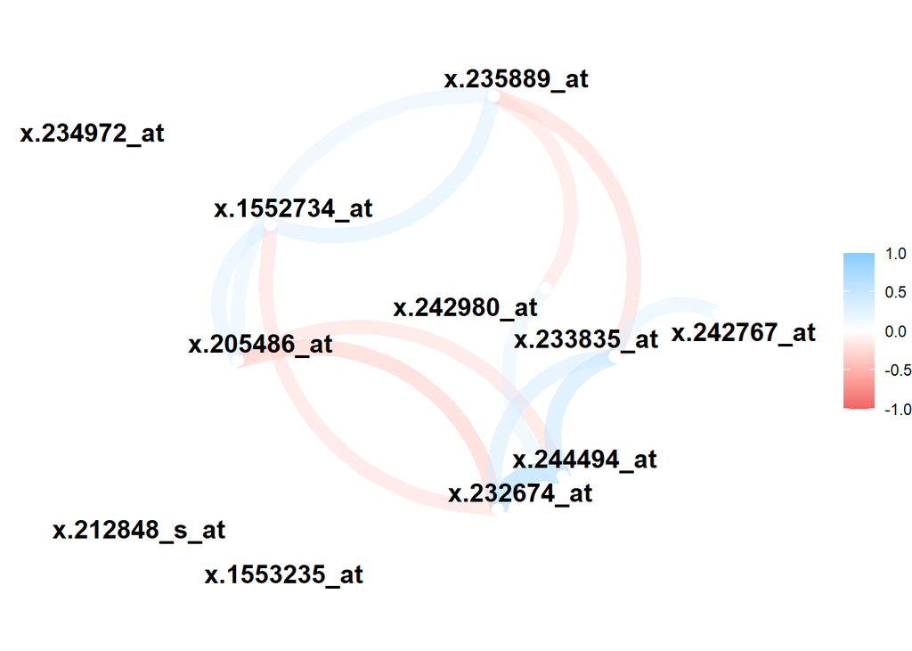

```r
network_plot(cor.autismo)
```

Representamos la matriz de correlaciones como una red, donde se aprecia la correlación entre las variables iniciales.

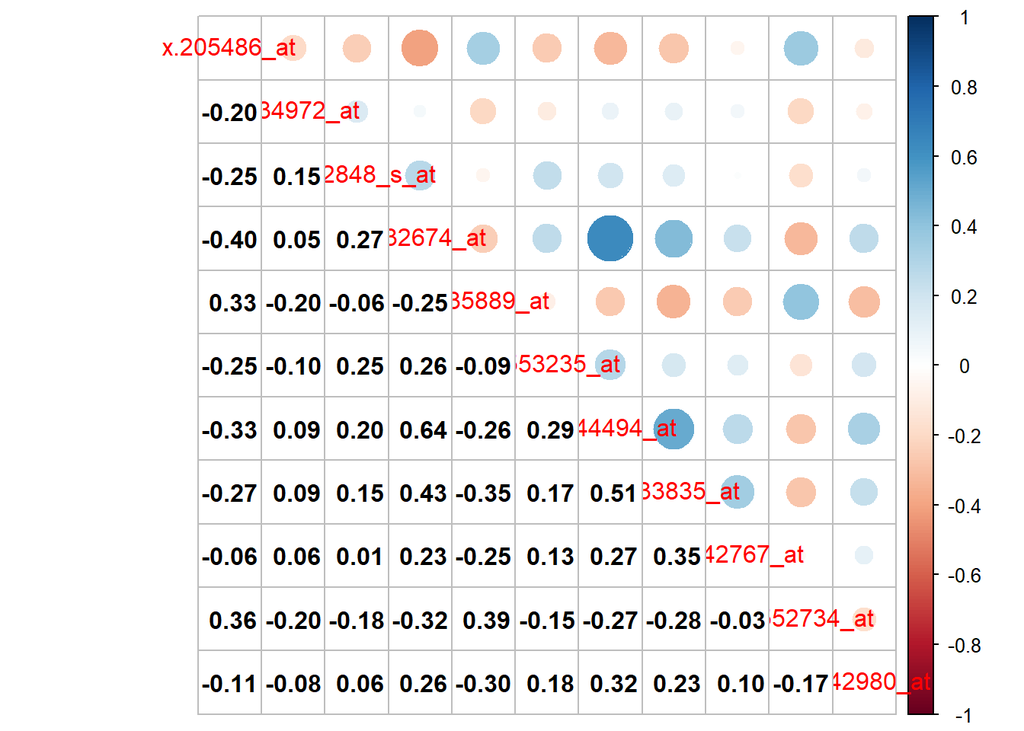

```r
library(corrplot)
cor.autismo=cor(datos.autismo[,-12])
corrplot.mixed(cor.autismo, lower.col = 1)
```

Visualizamos la matriz de correlacion resaltando por colores valores y posiciones.

Test de esfericidad de Barlett (contraste de idoneidad de PCA)

```r
library("psych")
cortest.bartlett(cor(datos.autismo[,1:11]), n = 124)
```

```
## $chisq
## [1] 276.2435
##
## $p.value
## [1] 3.189716e-31
##
## $df
## [1] 55
```

```r
library("REdaS")
bart_spher(datos.autismo[,1:11])
```

```
##  Bartlett's Test of Sphericity
##
## Call: bart_spher(x = datos.autismo[, 1:11])
##
##      X2 = 276.243
##      df = 55
## p-value < 2.22e-16
```

En este caso, p.value<0.05 por lo que rechazamos H0 de que la matriz de correlación es igual a la matriz identidad, por lo que las variables están correlacionadas y es idoneo realizar PCA.

No obstante, nos apoyaremos en el test KMO y KMOS para confirmarlo.

```r
KMO(datos.autismo[,1:11])
```

```
## Kaiser-Meyer-Olkin factor adequacy
## Call: KMO(r = datos.autismo[, 1:11])
## Overall MSA =  0.78
## MSA for each item =
##   x.205486_at   x.234972_at x.212848_s_at   x.232674_at   x.235889_at
##          0.82          0.57          0.76          0.79          0.74
##  x.1553235_at   x.244494_at   x.233835_at   x.242767_at  x.1552734_at
##          0.75          0.78          0.85          0.71          0.82
##   x.242980_at
##          0.76
```

```r
KMOS(datos.autismo[,1:11])
```

```
##
## Kaiser-Meyer-Olkin Statistics
##
## Call: KMOS(x = datos.autismo[, 1:11])
##
## Measures of Sampling Adequacy (MSA):
##   x.205486_at   x.234972_at x.212848_s_at   x.232674_at   x.235889_at
##     0.8185117     0.5698210     0.7590756     0.7894791     0.7430738
##  x.1553235_at   x.244494_at   x.233835_at   x.242767_at  x.1552734_at
##     0.7502516     0.7789906     0.8519948     0.7077633     0.8188344
##   x.242980_at
##     0.7636423
##
## KMO-Criterion: 0.7787607
```

Observamos KMO alto -> valor MSA mayor de 0.5 indicativo de PCA idóneo -> pasamos barlett y KMO -> ADECUADO PCA.

```r
library(FactoMineR)
```

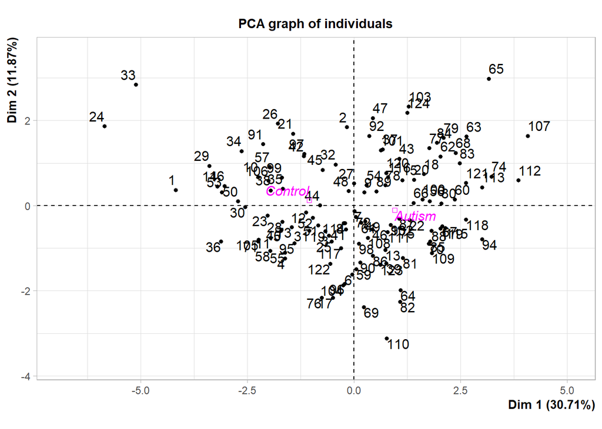

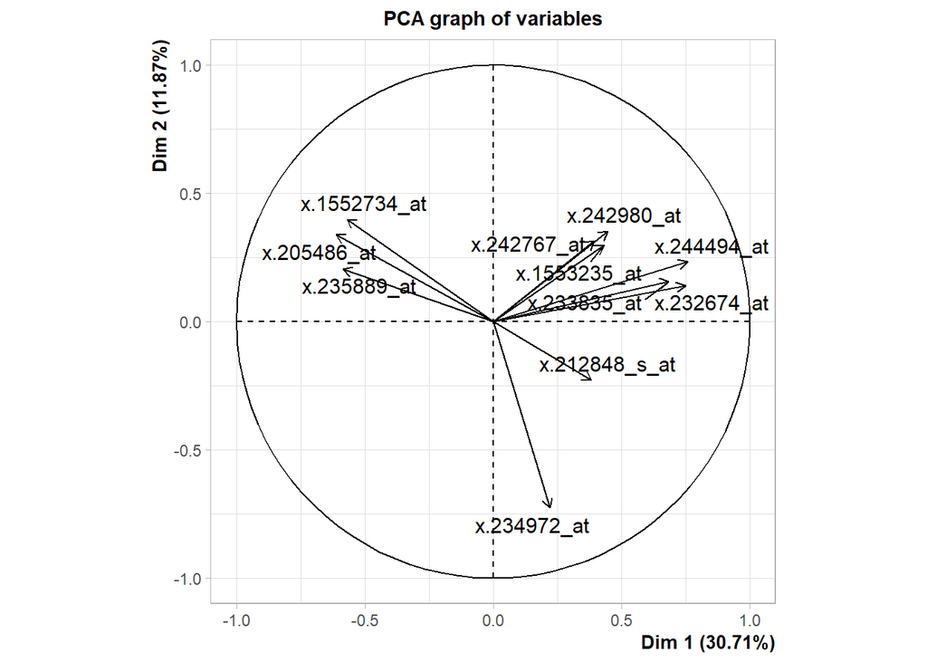

```r
o=par(mfrow=c(1,2))
autismo.pca <- PCA(datos.autismo, scale.unit=T, ncp=11, quali.sup = 12, graph=T, axes = c(1, 2))
```

*Interpretación*

En el primer gráfico, vemos como se distribuyen los individuos observados en la primera y segunda dimensión. En el segundo gráfico, vemos que cuanto menor sea el ángulo que forma la proyección de cada variable (flecha) sobre el eje de cada componente, mas próximo será a la componente y la caracteriza más a esa componente la variable(más peso tiene en esa componente). Siempre se representa de dos en dos dimensiones, componentes dos a dos y las voy analizando así (en la opción axes puedemos cambiar y ver todas las dimensiones).

En este caso, la que mayor carga posee es 232674_at ya que esta mas próximo al eje de la primera componente (correlacion positiva). Aunque en terminos numéricos el valor de contribución de la variable 244494_at sea mas alto, se distancia mas del eje que 232674_at porque contribuye un poco más a la segunda componente.

Las variables que presenten un angulo de 45% en el eje de 90% entre dos componentes, significa que esta a mitad del cuadrante, 45 y 45, no tiene mayor carga factorial ni en una ni en otra, por lo que tendra mas carga en otras componenentes. Y así ocurre si miramos la contribución de estas variables en la componente 11.

Por otro lado, si cambiamos axes y analizamos la contribucion numérica de la segunda y tercera vemos como variables con mas carga 234972_at en la CP 2 (correlacion negativa) y 212848_s_at en CP 3 (correlacion negativa bajita para la CP 2 y positiva alta para CP 3). Del mismo modo para las CP 4, 5 y 6 tendriamos otras variables que contribuyen destacadamente junto con las comentadas en algunas CP.

```r
summary(autismo.pca)
```

```
##
## Call:
## PCA(X = datos.autismo, scale.unit = T, ncp = 11, quali.sup = 12,
##      graph = T, axes = c(1, 2))
##
##
## Eigenvalues
##                        Dim.1   Dim.2   Dim.3   Dim.4   Dim.5   Dim.6   Dim.7
## Variance               3.378   1.306   1.202   1.001   0.804   0.764   0.640
## % of var.             30.711  11.873  10.928   9.103   7.310   6.943   5.819
## Cumulative % of var.  30.711  42.584  53.512  62.615  69.925  76.868  82.687
##                        Dim.8   Dim.9  Dim.10  Dim.11
## Variance               0.596   0.535   0.446   0.327
## % of var.              5.422   4.860   4.055   2.975
## Cumulative % of var.  88.109  92.970  97.025 100.000
##
## Individuals (the 10 first)
##                   Dist    Dim.1    ctr   cos2    Dim.2    ctr   cos2    Dim.3
## 1             |  4.874 | -4.182  4.174  0.736 |  0.369  0.084  0.006 |  1.150
## 2             |  3.060 | -0.173  0.007  0.003 |  1.842  2.094  0.362 |  0.358
## 3             |  3.452 | -0.588  0.083  0.029 | -0.707  0.309  0.042 | -1.335
## 4             |  2.447 | -1.613  0.621  0.434 | -1.244  0.955  0.258 |  0.058
## 5             |  2.767 | -1.716  0.703  0.385 | -0.588  0.213  0.045 | -0.244
## 6             |  2.061 | -0.044  0.000  0.000 | -1.617  1.614  0.616 | -0.323
## 7             |  2.322 |  0.008  0.000  0.000 | -0.124  0.009  0.003 |  0.337
## 8             |  1.869 | -0.245  0.014  0.017 | -0.413  0.105  0.049 |  1.196
## 9             |  2.495 |  0.246  0.014  0.010 |  0.309  0.059  0.015 | -1.318
## 10            |  3.072 | -2.243  1.201  0.533 |  0.674  0.281  0.048 |  0.776
##                  ctr   cos2
## 1              0.888  0.056 |
## 2              0.086  0.014 |
## 3              1.196  0.150 |
## 4              0.002  0.001 |
## 5              0.040  0.008 |
## 6              0.070  0.025 |
## 7              0.076  0.021 |
## 8              0.959  0.410 |
## 9              1.166  0.279 |
## 10             0.404  0.064 |
##
```

[output cut: 16 more lines]

```
## x.232674_at    0.026 |
## x.235889_at    0.204 |
## x.1553235_at   0.259 |
## x.244494_at    0.001 |
## x.233835_at    0.060 |
## x.242767_at    0.201 |
## x.1552734_at   0.001 |
##
## Supplementary categories
##                   Dist    Dim.1   cos2 v.test    Dim.2   cos2 v.test    Dim.3
## Autism        |  1.002 |  0.957  0.913  6.062 | -0.109  0.012 -1.110 |  0.007
## Control       |  1.103 | -1.055  0.913 -6.062 |  0.120  0.012  1.110 | -0.008
##                 cos2 v.test
## Autism         0.000  0.079 |
## Control        0.000 -0.079 |
```

**ANALISIS DE EXPRESION DE LAS COMPONENTES EXTRAIDAS E INTERPRETACION**

Para ello, podemos seguir el criterio de Kaiser, donde seleccionaremos todas aquellas dimensiones que superen una varianza de 1 o bien seleccionar aquellas que reunan en torno a un 80% de varianza acumulativa. No obstante, para reforzar este criterio vamos a realizar un método de seleccion de componentes.

```r
library(nFactors)
ap <- parallel(subject=nrow(datos.autismo[,1:11]),var=ncol(datos.autismo[,1:11]),rep=100,cent=.95)
nS <- nScree(ev$values,ap$eigen$qevpea)
vp <- min(nS$Components)+1;
vp
```

```
## [1] 2
```

Este método determina el número de componentes principales a retener como el mínimo de los componentes según el método de Scree más 1. Este paso es comúnmente utilizado para evitar subestimar la cantidad de componentes. Por tanto, debemos extraer como mínimo las 2 primeras componentes, pero seleccionamos hasta la cuarta reteniendo un 62% de información total aproximadamente, ya que a partir de aqui las siguientes dimensiones retienen un valor de varianza inferior a 1.

```r
autismo.comp=autismo.pca$ind$coord[,1:4]
```

Visualización de la correlación entre variables.

```r
library(factoextra)
```

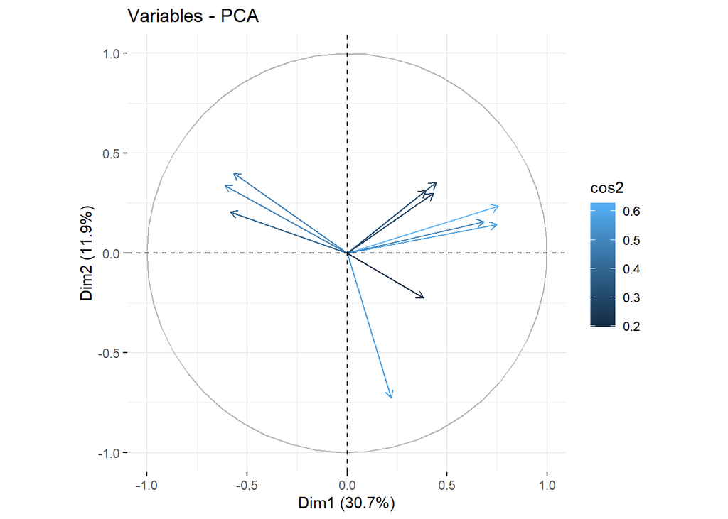

```r
library(ggplot2)

fviz_pca_var(autismo.pca, col.var = "cos2",
             addlabels = TRUE,
             geom.var = "arrow",
             labelsize = 2,
             repel = TRUE)
```

Podemos ver en este caso las variables (representadas por su vector cos2) que estan correlacionadas positivamente en cada dimensión (juntas en el mismo cuadrante). Tambien las variables que se correlacionan negativamente en cada dimensión (apuntando al cuadrante opuesto).

Visualización del procentaje de varianza explicacada en cada dimension o componente.

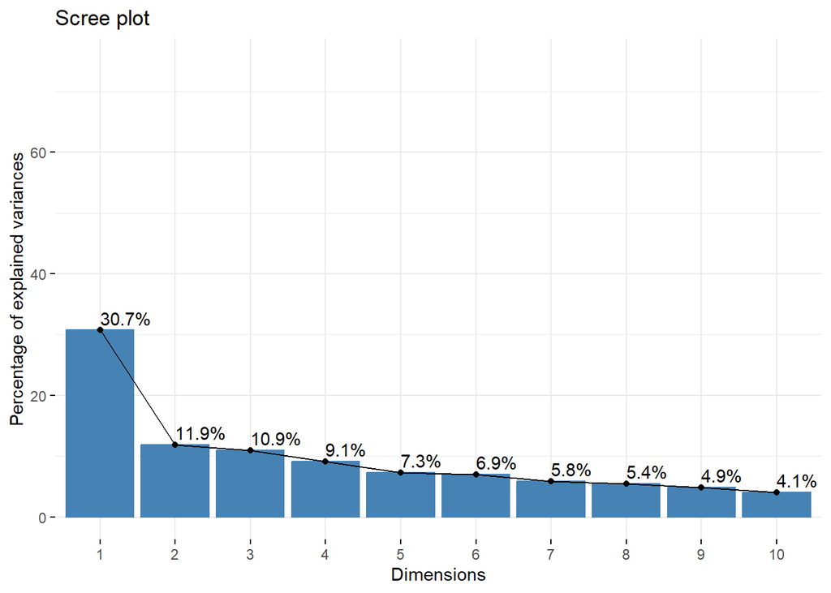

```r
fviz_screeplot(autismo.pca, addlabels = TRUE, ylim = c(0, 75))
```

## 3. Representa conjuntamente las expresiones génicas (variables) y los individuos de la muestra (observaciones). Interpreta la nube de puntos.

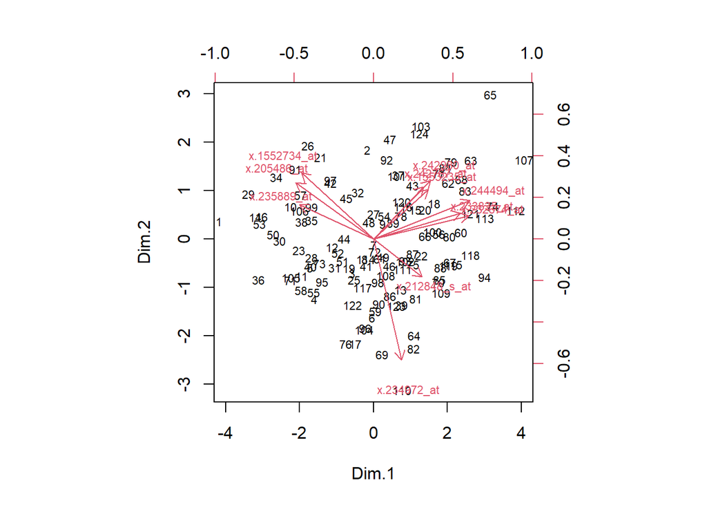

```r
biplot(autismo.pca$ind$coord[,1:2],autismo.pca$var$coord[,1:2],xlim=c(-4,4), cex = 0.7)
```

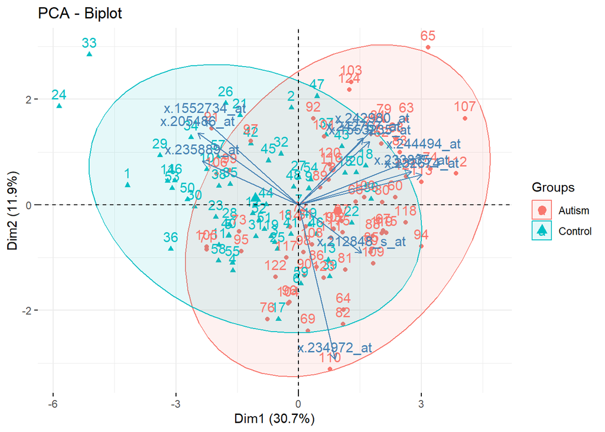

```r
biplot <- fviz_pca_biplot(autismo.pca, axes = c(1, 2), habillage = datos.autismo$factor, addEllipses = TRUE)
biplot
```

*Interpretación*

Los individuos que están en el origen no estan afectadas por ninguna componente –> todas las variables cerca o en la media. Ejemplos: individuos 7, 72 y 61. En contraste, los individuos que se situan cerca o sobre la proyección de cada variable sobre las componentes (en esta grafica en concreto dimensiones 1 y 2) serán aquellos que contribuyan más a la retención de varianza por parte de dicha variable. Por otro lado, los mas alejados del centro del eje y de la proyeccion de variables serán considerados valores outliers. Por último, comentar que la presencia de elipses pone de manifiesto visual el gran solapamiento que existe entre ambas clases o grupos(variable factor) de nuestro conjunto. Este solapamiento se observa en todas las dimensiones (cambiando axes en la función).